# Regression problem

Mohammad Hajjaj 2

2023-12-10

## R Markdown

```r
library(tidyverse)
library(dplyr)
library(reshape2)
library(gridExtra)
library(caret)
library(rpart)
library(randomForest)
library(boot)
```

```r
library(coefplot)
library(ggrepel)
library(rstanarm)
library(readr)
library(broom)
library(caret)
library(glmnet)
library(nnet)
library(xgboost)
library(broom.mixed)
library(splines)
#library(MASS)
library(glmnet)
library(e1071)
df <- readr::read_csv("paint_project_train_data.csv", col_names = TRUE)
df_test2 <- readr::read_csv("df_test_enhanced.csv", col_names = TRUE)
df_test <- readr::read_csv("paint_project_holdout_data.csv", col_names = TRUE)
```

| ### Regression task |
| --- |
| ### Regression iiA ) Linear models: |

```r
dfii <- df %>%
  mutate(y = boot::logit( (response - 0) / (100 - 0) ) ) %>%
  select(R, G, B, Lightness, Saturation, Hue, y)
```

Visualize the relation:

```r
continuous_vars <- c("R", "G", "B", "Hue")

scatter_plots <- lapply(1:(length(continuous_vars) - 1), function(i) {
  var1 <- continuous_vars[i]
  lapply((i + 1):length(continuous_vars), function(j) {
    var2 <- continuous_vars[j]
    ggplot(dfii, aes(x = !!sym(var1), y = !!sym(var2))) +
      geom_point() +
      geom_smooth(method = "lm", formula = y ~ x) +
      labs(title = paste("Scatter Plot of", var1, "vs.", var2))
  })
})
```

```
## [[1]]
## [[1]][[1]]
```

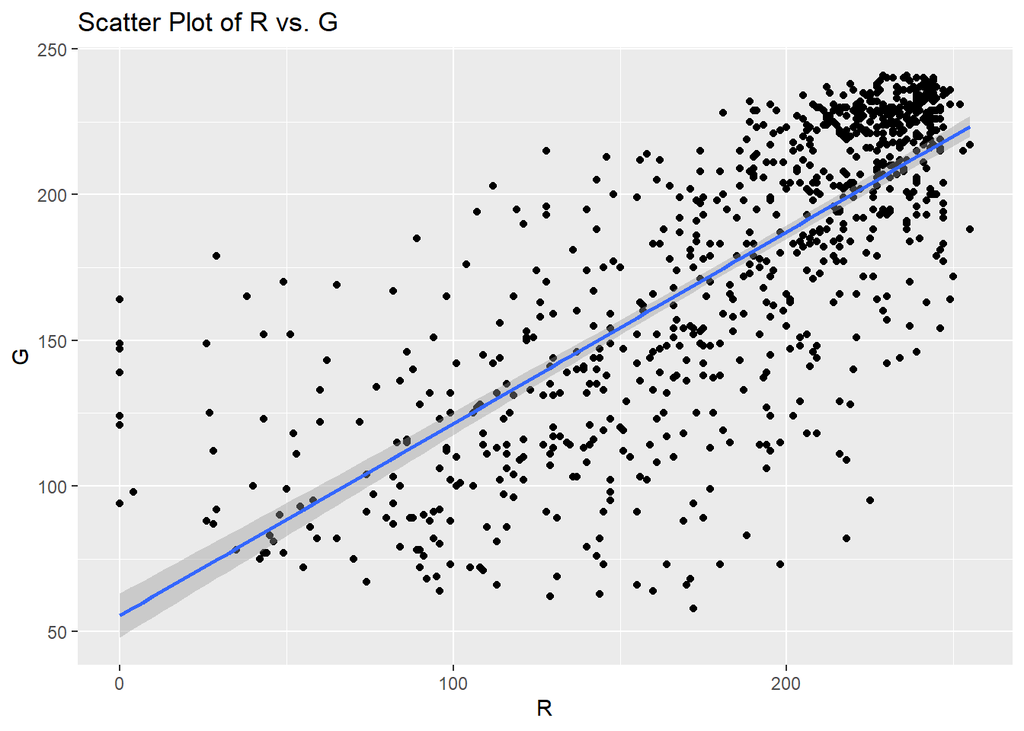

```
##
## [[1]][[2]]
```

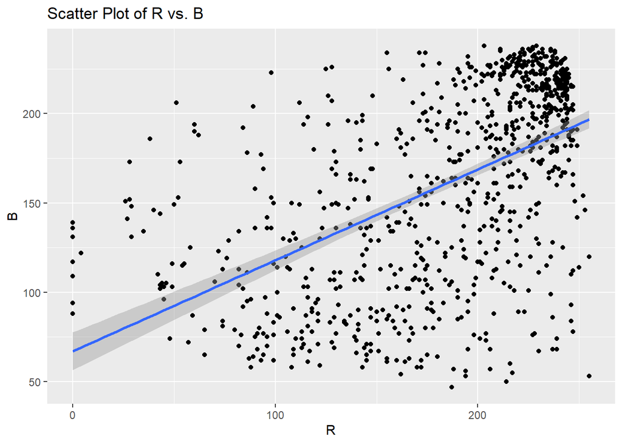

```
##
## [[1]][[3]]
```

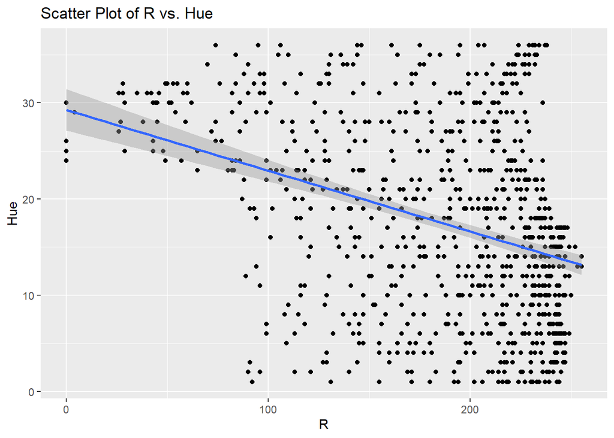

```
##
##
## [[2]]
## [[2]][[1]]
```

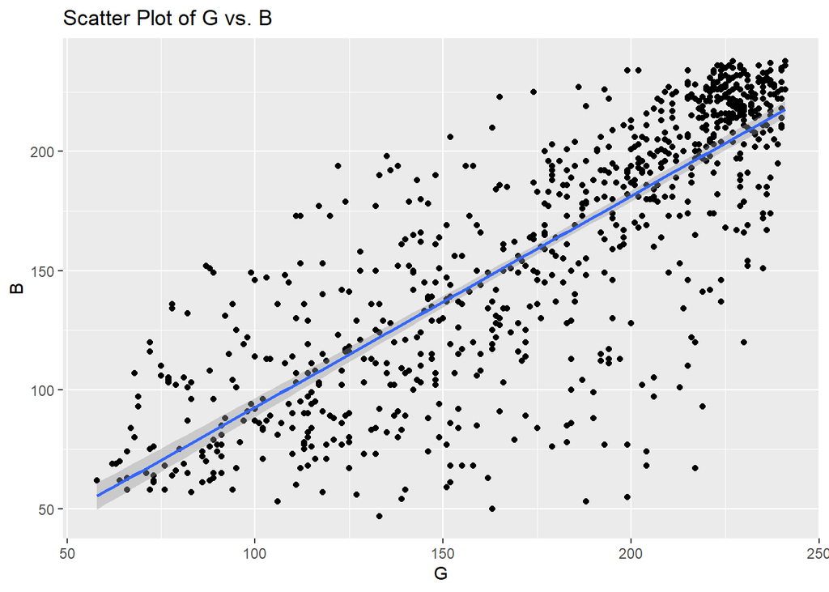

```
##
## [[2]][[2]]
```

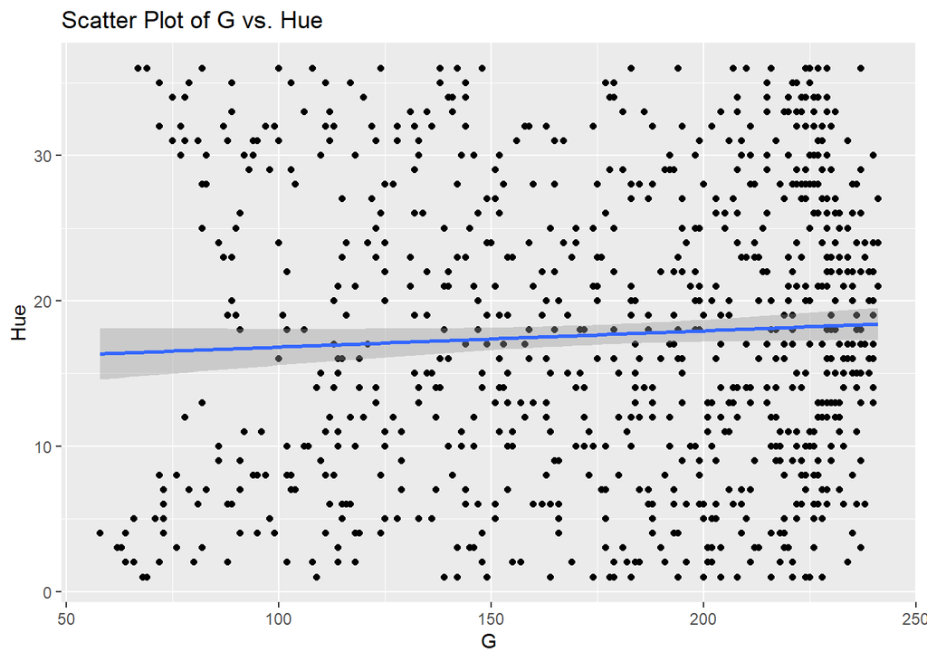

```
##
##
## [[3]]
## [[3]][[1]]
```

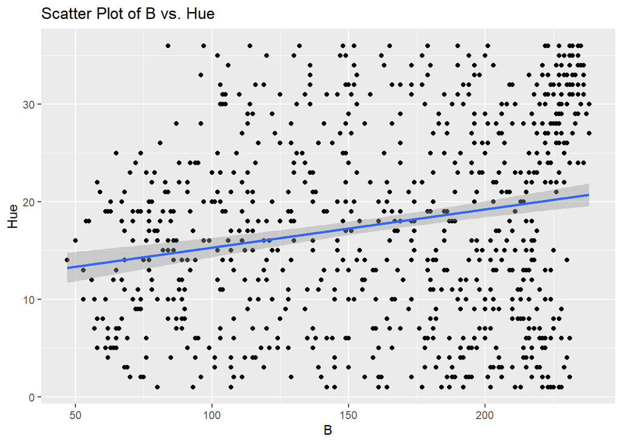

```r
scatter_plots
```

#### Part ii: Regression iiA ) Linear models:

## 1) First I’m going to train 10 lenir modle:

```r
# Intercept only model (no inputs)
model_1 <- lm(y ~ 1, data = dfii)

# Categorical variables only (Lightness and Saturation as factors)
model_2 <- lm(y ~ factor(Lightness) + factor(Saturation), data = dfii)

# Continuous Variables Only (R, G, B)
model_3 <- lm(y ~ R + G + B + Hue, data = dfii)

# All Variables including interactions
model_4 <- lm(y ~ R + G + B + Hue + factor(Lightness) + factor(Saturation), data = dfii)

# Interaction of Categorical Inputs with All Continuous Inputs (Main Effects)
model_5 <- lm(y ~ (factor(Lightness) + factor(Saturation)) * (R + G + B + Hue), data = dfii)

# Add Categorical Inputs to All Main Effects and All Pairwise Interactions of Continuous Inputs
model_6 <- lm(y ~ (R + G + B + Hue)^2 + factor(Lightness) + factor(Saturation), data = dfii)

# Interaction of Categorical Inputs with All Main Effects and All Pairwise Interactions of Continuous Inputs
model_7 <- lm(y ~ (Lightness + Saturation) * (R + G + B + Hue)^2, data = dfii)

# Models with Basis Functions of Your Choice: Polynomial basis
model_8 <- lm(y ~ poly(R, 2) + poly(G, 2) + poly(B, 2) + poly(Hue, 2) + factor(Lightness) + factor(Saturation), data = dfii)

# Model 9: Natural splines (for R only)
model_9 <- lm(y ~ splines::ns(R, 3) + G + B + Hue + factor(Lightness) + factor(Saturation), data = dfii)

# Model 10: Quadratic term for Hue (for R, G, B, and Hue)
model_10 <- lm(y ~ R + G + B + I(Hue^2) + Lightness * Saturation, data = dfii)
```

```r
# Save each model as an RDS file
write_rds(model_1, "model_1.rds")
write_rds(model_2, "model_2.rds")
write_rds(model_3, "model_3.rds")
write_rds(model_4, "model_4.rds")
write_rds(model_5, "model_5.rds")
write_rds(model_6, "model_6.rds")
write_rds(model_7, "model_7.rds")
write_rds(model_8, "model_8.rds")
write_rds(model_9, "model_9.rds")
write_rds(model_10, "model_10.rds")
```

## 2)

```r
tr_set_rmse <- numeric(9)
tr_set_rmse[1] <- modelr::rmse(model_1, dfii )
tr_set_rmse[2] <- modelr::rmse(model_2, dfii )
tr_set_rmse[3] <- modelr::rmse(model_3, dfii )
tr_set_rmse[4] <- modelr::rmse(model_4, dfii )
tr_set_rmse[5] <- modelr::rmse(model_5, dfii )
tr_set_rmse[6] <- modelr::rmse(model_6, dfii )
tr_set_rmse[7] <- modelr::rmse(model_7, dfii )
tr_set_rmse[8] <- modelr::rmse(model_8, dfii )
tr_set_rmse[9] <- modelr::rmse(model_9, dfii )
tr_set_rmse[10] <- modelr::rmse(model_10, dfii )


best_model_index <- which.min(tr_set_rmse)

cat("Training Set RMSE for Each Model:\n")
```

```
## Training Set RMSE for Each Model:
```

```r
for (i in 1:10) {
  cat(paste("Degree(", i, ") : [", tr_set_rmse[i], "]\n"))
}
```

```
## Degree( 1 ) : [ 1.18363270081154 ]
## Degree( 2 ) : [ 0.402030004569239 ]
## Degree( 3 ) : [ 0.129098482837147 ]
## Degree( 4 ) : [ 0.0877152049032932 ]
## Degree( 5 ) : [ 0.0554122368068308 ]
## Degree( 6 ) : [ 0.0778534603826494 ]
## Degree( 7 ) : [ 0.0408391217079345 ]
## Degree( 8 ) : [ 0.0743800692654818 ]
## Degree( 9 ) : [ 0.0853449844141781 ]
## Degree( 10 ) : [ 0.0847518801377351 ]
```

```r
cat("\nBest Model Degree (", best_model_index, ") with lowest training set RMSE: ",
    tr_set_rmse[best_model_index], "\n")
```

```
##
## Best Model Degree ( 7 ) with lowest training set RMSE:  0.04083912
```

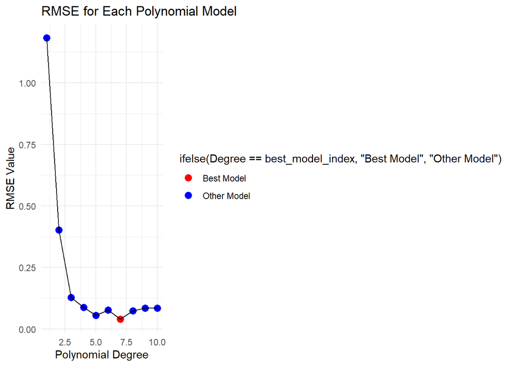

```r
data_to_plot <- tibble(
  Degree = 1:10,
  RMSE = tr_set_rmse
)

# Plot
p <- ggplot(data_to_plot, aes(x = Degree, y = RMSE)) +
  geom_point(aes(color = ifelse(Degree == best_model_index, "Best Model", "Other Model")), size = 3) +  # Highlight the best model
  geom_line() +
  labs(title = "RMSE for Each Polynomial Model",
       x = "Polynomial Degree",
       y = "RMSE Value") +
  scale_color_manual(values = c("Best Model" = "red", "Other Model" = "blue")) +
  theme_minimal()

print(p)
```

### 4) R-squared for each model:

```r
tr_set_r_squared  <- numeric(16)
tr_set_r_squared[1] <-  modelr::rsquare(model_1, data = dfii)
tr_set_r_squared[2] <-  modelr::rsquare(model_2, data = dfii)
tr_set_r_squared[3] <-  modelr::rsquare(model_3, data = dfii)
tr_set_r_squared[4] <-  modelr::rsquare(model_4, data = dfii)
tr_set_r_squared[5] <-  modelr::rsquare(model_5, data = dfii)
tr_set_r_squared[6] <-  modelr::rsquare(model_6, data = dfii)
tr_set_r_squared[7] <-  modelr::rsquare(model_7, data = dfii)
tr_set_r_squared[8] <-  modelr::rsquare(model_8, data = dfii)
tr_set_r_squared[9] <-  modelr::rsquare(model_9, data = dfii)
tr_set_r_squared[10] <-  modelr::rsquare(model_10, data = dfii)

rsquared_tibble <- tibble(Degree = 1:16, R_squared = tr_set_r_squared)


print(rsquared_tibble)
```

```
## # A tibble: 16 × 2
##    Degree R_squared
##     <int>     <dbl>
##  1      1     0
##  2      2     0.885
##  3      3     0.988
##  4      4     0.995
##  5      5     0.998
##  6      6     0.996
##  7      7     0.999
##  8      8     0.996
##  9      9     0.995
## 10     10     0.995
## 11     11     0
## 12     12     0
## 13     13     0
## 14     14     0
## 15     15     0
## 16     16     0
```

The best Models is 7, 5 and 8 the higher the value is, the closer to one, the better ## 5 ) ## summary model_7

```r
summary(model_7)
```

```
##
## Call:
## lm(formula = y ~ (Lightness + Saturation) * (R + G + B + Hue)^2,
##     data = dfii)
##
## Residuals:
##       Min        1Q    Median        3Q       Max
## -0.233973 -0.023247 -0.001102  0.022124  0.201412
##
## Coefficients:
##                            Estimate Std. Error t value Pr(>|t|)
## (Intercept)              -4.782e+00  3.131e-01 -15.271  < 2e-16 ***
## Lightnessdeep             4.939e-01  2.378e-01   2.077 0.038131 *
## Lightnesslight            1.102e+01  1.708e+00   6.450 2.10e-10 ***
## Lightnessmidtone          3.742e+00  4.747e-01   7.883 1.25e-14 ***
## Lightnesspale             2.460e+01  3.356e+00   7.330 6.45e-13 ***
## Lightnesssaturated        2.235e+00  3.115e-01   7.175 1.86e-12 ***
## Lightnesssoft             6.570e+00  7.647e-01   8.591  < 2e-16 ***
## Saturationgray           -1.148e-01  2.797e-01  -0.411 0.681526
## Saturationmuted          -3.031e-01  2.408e-01  -1.259 0.208560
## Saturationneutral        -1.512e-01  2.568e-01  -0.589 0.556208
## Saturationpure           -1.225e-01  3.184e-01  -0.385 0.700495
## Saturationshaded         -6.223e-02  2.535e-01  -0.245 0.806191
## Saturationsubdued        -3.923e-01  2.611e-01  -1.503 0.133386
## R                         8.432e-03  1.890e-03   4.461 9.53e-06 ***
## G                         1.737e-02  2.291e-03   7.582 1.10e-13 ***
## B                         9.959e-03  2.059e-03   4.837 1.63e-06 ***
## Hue                       8.036e-03  1.264e-02   0.636 0.525200
## R:G                      -1.634e-05  6.036e-06  -2.706 0.006967 **
## R:B                      -1.741e-05  8.436e-06  -2.064 0.039398 *
## R:Hue                    -3.375e-05  6.661e-05  -0.507 0.612528
## G:B                      -1.677e-05  1.342e-05  -1.249 0.211982
## G:Hue                     4.219e-05  5.500e-05   0.767 0.443352
## B:Hue                    -1.305e-04  7.460e-05  -1.749 0.080692 .
## Lightnessdeep:R          -7.922e-04  9.529e-04  -0.831 0.406072
## Lightnesslight:R         -3.478e-02  7.982e-03  -4.357 1.52e-05 ***
## Lightnessmidtone:R       -1.259e-02  2.093e-03  -6.016 2.90e-09 ***
## Lightnesspale:R          -6.586e-02  1.990e-02  -3.309 0.000985 ***
## Lightnesssaturated:R     -8.552e-03  1.366e-03  -6.260 6.76e-10 ***
## Lightnesssoft:R          -1.965e-02  3.593e-03  -5.467 6.39e-08 ***
```

[output cut: 105 more lines]

```
## Saturationpure:G:Hue      5.673e-05  5.768e-05   0.984 0.325650
## Saturationshaded:G:Hue   -2.671e-05  8.560e-05  -0.312 0.755132
## Saturationsubdued:G:Hue  -1.324e-04  7.025e-05  -1.885 0.059787 .
## Saturationgray:B:Hue      2.232e-04  1.531e-04   1.458 0.145257
## Saturationmuted:B:Hue     3.204e-05  5.489e-05   0.584 0.559617
## Saturationneutral:B:Hue   1.738e-04  8.440e-05   2.059 0.039866 *
## Saturationpure:B:Hue     -4.786e-05  6.073e-05  -0.788 0.430981
## Saturationshaded:B:Hue    1.730e-05  7.242e-05   0.239 0.811232
## Saturationsubdued:B:Hue   2.092e-04  6.741e-05   3.103 0.001996 **
## ---
## Signif. codes:  0 '***' 0.001 '**' 0.01 '*' 0.05 '.' 0.1 ' ' 1
##
## Residual standard error: 0.04486 on 692 degrees of freedom
## Multiple R-squared:  0.9988, Adjusted R-squared:  0.9986
## F-statistic:  4089 on 142 and 692 DF,  p-value: < 2.2e-16
```

## coefficient plot for linear relationship model_7

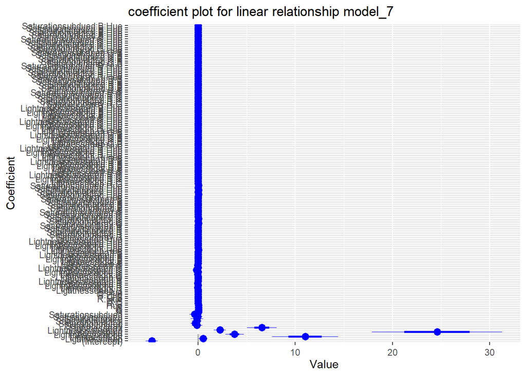

```r
coefplot::coefplot(model_7)+
  labs(title = 'coefficient plot for linear relationship model_7')
```

## summary model_5

```r
summary(model_5)
```

```
##
## Call:
## lm(formula = y ~ (factor(Lightness) + factor(Saturation)) * (R +
##     G + B + Hue), data = dfii)
##
## Residuals:
##       Min        1Q    Median        3Q       Max
## -0.259142 -0.035041 -0.003511  0.027300  0.250835
##
## Coefficients:
##                                  Estimate Std. Error t value Pr(>|t|)
## (Intercept)                    -3.877e+00  5.053e-02 -76.719  < 2e-16 ***
## factor(Lightness)deep           2.185e-01  5.308e-02   4.117 4.26e-05 ***
## factor(Lightness)light         -2.287e+00  1.448e-01 -15.791  < 2e-16 ***
## factor(Lightness)midtone       -3.056e-01  7.520e-02  -4.064 5.31e-05 ***
## factor(Lightness)pale          -4.068e+00  2.119e-01 -19.195  < 2e-16 ***
## factor(Lightness)saturated      6.354e-02  6.322e-02   1.005 0.315167
## factor(Lightness)soft          -1.161e+00  9.038e-02 -12.842  < 2e-16 ***
## factor(Saturation)gray         -3.591e-01  4.674e-02  -7.683 4.72e-14 ***
## factor(Saturation)muted        -1.104e-01  3.641e-02  -3.031 0.002522 **
## factor(Saturation)neutral      -4.037e-01  3.850e-02 -10.487  < 2e-16 ***
## factor(Saturation)pure          3.454e-02  4.047e-02   0.853 0.393738
## factor(Saturation)shaded       -2.915e-01  3.796e-02  -7.679 4.86e-14 ***
## factor(Saturation)subdued      -2.431e-01  3.898e-02  -6.238 7.31e-10 ***
## R                               3.909e-03  1.819e-04  21.493  < 2e-16 ***
## G                               1.492e-02  2.754e-04  54.183  < 2e-16 ***
## B                               3.474e-03  3.765e-04   9.226  < 2e-16 ***
## Hue                            -6.730e-03  1.109e-03  -6.069 2.02e-09 ***
## factor(Lightness)deep:R         3.739e-05  1.942e-04   0.193 0.847370
## factor(Lightness)light:R        2.140e-03  5.044e-04   4.243 2.47e-05 ***
## factor(Lightness)midtone:R      3.136e-04  2.762e-04   1.136 0.256430
## factor(Lightness)pale:R         3.743e-03  8.956e-04   4.180 3.26e-05 ***
## factor(Lightness)saturated:R   -1.606e-05  2.203e-04  -0.073 0.941904
## factor(Lightness)soft:R         1.017e-03  3.852e-04   2.641 0.008439 **
## factor(Lightness)deep:G        -1.372e-03  2.761e-04  -4.970 8.25e-07 ***
## factor(Lightness)light:G        7.991e-03  6.993e-04  11.427  < 2e-16 ***
## factor(Lightness)midtone:G      1.574e-03  3.898e-04   4.038 5.93e-05 ***
## factor(Lightness)pale:G         1.385e-02  1.082e-03  12.798  < 2e-16 ***
## factor(Lightness)saturated:G   -2.790e-04  2.982e-04  -0.936 0.349815
## factor(Lightness)soft:G         4.932e-03  5.340e-04   9.237  < 2e-16 ***
```

[output cut: 27 more lines]

```
## factor(Saturation)pure:B       -8.680e-04  1.879e-04  -4.621 4.48e-06 ***
## factor(Saturation)shaded:B      3.125e-05  3.225e-04   0.097 0.922827
## factor(Saturation)subdued:B     1.236e-04  2.570e-04   0.481 0.630819
## factor(Saturation)gray:Hue      1.987e-04  1.427e-03   0.139 0.889268
## factor(Saturation)muted:Hue    -8.850e-04  1.022e-03  -0.866 0.386646
## factor(Saturation)neutral:Hue   3.673e-03  1.140e-03   3.221 0.001330 **
## factor(Saturation)pure:Hue      1.616e-03  9.973e-04   1.620 0.105598
## factor(Saturation)shaded:Hue    2.363e-04  1.068e-03   0.221 0.824907
## factor(Saturation)subdued:Hue   3.258e-04  1.106e-03   0.294 0.768477
## ---
## Signif. codes:  0 '***' 0.001 '**' 0.01 '*' 0.05 '.' 0.1 ' ' 1
##
## Residual standard error: 0.0577 on 770 degrees of freedom
## Multiple R-squared:  0.9978, Adjusted R-squared:  0.9976
## F-statistic:  5477 on 64 and 770 DF,  p-value: < 2.2e-16
```

## coefficient plot for linear relationship model_5’

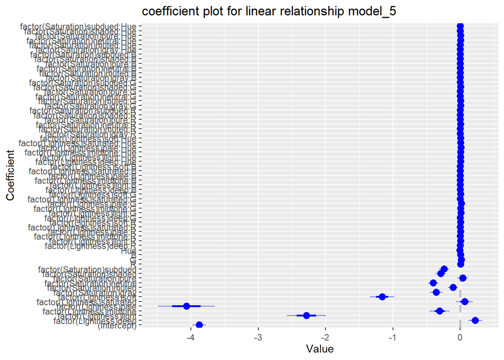

```r
coefplot::coefplot(model_5)+
  labs(title = 'coefficient plot for linear relationship model_5')
```

## summary model_8

```r
summary(model_8)
```

```
##
## Call:
## lm(formula = y ~ poly(R, 2) + poly(G, 2) + poly(B, 2) + poly(Hue,
##     2) + factor(Lightness) + factor(Saturation), data = dfii)
##
## Residuals:
##       Min        1Q    Median        3Q       Max
## -0.314902 -0.046206 -0.003151  0.041397  0.314575
##
## Coefficients:
##                             Estimate Std. Error t value Pr(>|t|)
## (Intercept)                -0.100934   0.020504  -4.923 1.03e-06 ***
## poly(R, 2)1                 8.002914   0.185705  43.095  < 2e-16 ***
## poly(R, 2)2                 1.057948   0.103643  10.208  < 2e-16 ***
## poly(G, 2)1                22.762514   0.285322  79.778  < 2e-16 ***
## poly(G, 2)2                 1.273611   0.110338  11.543  < 2e-16 ***
## poly(B, 2)1                 5.825199   0.301994  19.289  < 2e-16 ***
## poly(B, 2)2                 0.944604   0.119788   7.886 1.00e-14 ***
## poly(Hue, 2)1              -0.275385   0.106795  -2.579 0.010094 *
## poly(Hue, 2)2              -0.710183   0.123158  -5.766 1.15e-08 ***
## factor(Lightness)deep       0.086348   0.013207   6.538 1.10e-10 ***
## factor(Lightness)light     -0.039445   0.029844  -1.322 0.186636
## factor(Lightness)midtone   -0.031420   0.024323  -1.292 0.196810
## factor(Lightness)pale       0.067064   0.031536   2.127 0.033754 *
## factor(Lightness)saturated  0.055068   0.019255   2.860 0.004346 **
## factor(Lightness)soft      -0.063472   0.027485  -2.309 0.021174 *
## factor(Saturation)gray     -0.037091   0.011894  -3.119 0.001881 **
## factor(Saturation)muted    -0.011678   0.009695  -1.205 0.228721
## factor(Saturation)neutral  -0.048270   0.010080  -4.789 2.00e-06 ***
## factor(Saturation)pure      0.025427   0.010075   2.524 0.011795 *
## factor(Saturation)shaded   -0.033895   0.009914  -3.419 0.000660 ***
## factor(Saturation)subdued  -0.034794   0.009853  -3.531 0.000437 ***
## ---
## Signif. codes:  0 '***' 0.001 '**' 0.01 '*' 0.05 '.' 0.1 ' ' 1
##
## Residual standard error: 0.07533 on 814 degrees of freedom
## Multiple R-squared:  0.9961, Adjusted R-squared:  0.996
## F-statistic: 1.027e+04 on 20 and 814 DF,  p-value: < 2.2e-16
```

## coefficient plot for linear relationship model_8

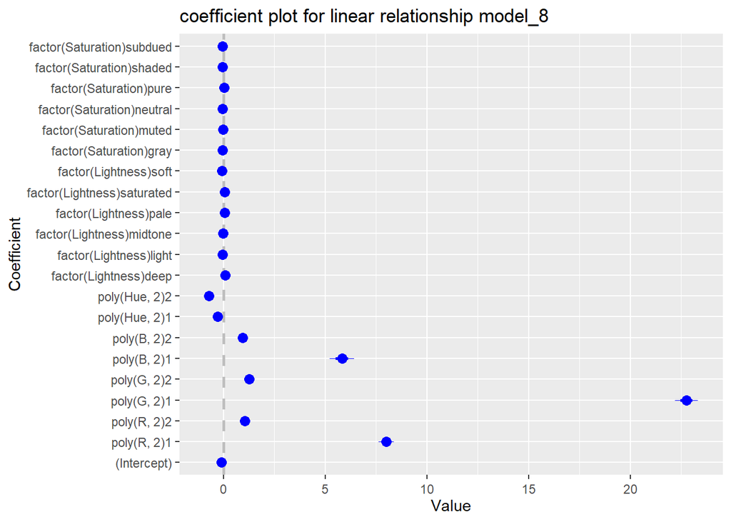

```r
coefplot::coefplot(model_8)+
  labs(title = 'coefficient plot for linear relationship model_8')
```

##coefficient plot for linear relationship model_7,model_5,model_8

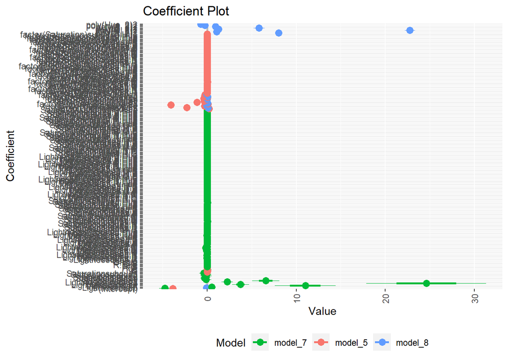

```r
coefplot::multiplot(model_7,model_5,model_8)
```

```r
extract_metrics <- function(mod, mod_name)
{
  broom::glance(mod) %>% mutate(mod_name = mod_name)
}
```

```r
all_metrics <- purrr::map2_dfr(list(model_1, model_2, model_3, model_4, model_5, model_6,model_7,model_8,model_9,model_10),
                               as.character(1:10),
                               extract_metrics)
```

```r
all_metrics %>% glimpse()
```

```
## Rows: 10
## Columns: 13
## $ r.squared     <dbl> 0.0000000, 0.8846326, 0.9881038, 0.9945082, 0.9978083, 0…
## $ adj.r.squared <dbl> 0.0000000, 0.8829484, 0.9880465, 0.9944008, 0.9976262, 0…
## $ sigma         <dbl> 1.18434210, 0.40519660, 0.12948675, 0.08862198, 0.057703…
## $ statistic     <dbl> NA, 525.2554, 17235.0403, 9258.1844, 5477.4752, 8494.316…
## $ p.value       <dbl> NA, 0, 0, 0, 0, 0, 0, 0, 0, 0
## $ df            <dbl> NA, 12, 4, 16, 64, 22, 142, 20, 18, 52
## $ logLik        <dbl> -1325.5849, -423.9378, 524.5814, 847.2924, 1230.8036, 94…
## $ AIC           <dbl> 2655.1698, 875.8757, -1037.1628, -1658.5849, -2329.6072,…
## $ BIC           <dbl> 2664.6246, 942.0597, -1008.7982, -1573.4911, -2017.5967,…
## $ deviance      <dbl> 1169.823619, 134.959484, 13.916459, 6.424454, 2.563881, …
## $ df.residual   <int> 834, 822, 830, 818, 770, 812, 692, 814, 816, 782
## $ nobs          <int> 835, 835, 835, 835, 835, 835, 835, 835, 835, 835
## $ mod_name      <chr> "1", "2", "3", "4", "5", "6", "7", "8", "9", "10"
```

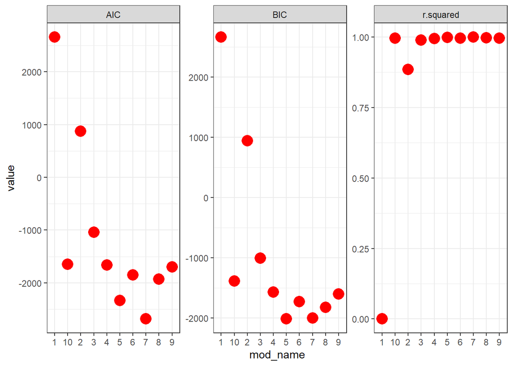

```r
all_metrics %>%
  #select(mod_name,value, AICc, BIC)  %>%
  pivot_longer(cols = c("r.squared", "AIC", "BIC"), names_to = "name", values_to = "value") %>%
  ggplot(mapping = aes(x = mod_name, y = value)) +
  geom_point(size = 5, color = 'red') +
  facet_wrap(~name, scales = "free_y") +
  theme_bw()
```

#### Part ii: Regression iiB ) Bayesian Linear models:

##1) Firts, Best Model from iiA, model_7, # Interaction of Categorical Inputs with All Main Effects and All Pairwise Interactions of Continuous Inputs ## model_7 <- lm(y ~ (factor(Lightness) + factor(Saturation)) * (R + G + B + Hue)^2, data = dfii)

### rload bayesian_model_7 and bayesian_model_3

```r
bayesian_model_3_rd <- read_rds("bayesian_model_3.rds")
bayesian_model_7_rd <- read_rds("bayesian_model_7.rds")
```

```r
posterior_interval(bayesian_model_7_rd)
```

```
##                                             5%           95%
## (Intercept)                      -5.192402e+00 -4.163160e+00
## factor(Lightness)deep             3.447407e-02  8.269092e-01
## factor(Lightness)light            6.481718e+00  1.172944e+01
## factor(Lightness)midtone          2.780552e+00  4.310963e+00
## factor(Lightness)pale             1.037297e+01  1.967098e+01
## factor(Lightness)saturated        1.614810e+00  2.645218e+00
## factor(Lightness)soft             4.847739e+00  7.334306e+00
## factor(Saturation)gray           -6.312315e-01  2.872936e-01
## factor(Saturation)muted          -7.096217e-01  8.177364e-02
## factor(Saturation)neutral        -6.049878e-01  2.307918e-01
## factor(Saturation)pure           -6.280892e-01  4.104187e-01
## factor(Saturation)shaded         -5.253308e-01  3.077051e-01
## factor(Saturation)subdued        -8.462327e-01  1.436814e-02
## R                                 5.031237e-03  1.127798e-02
## G                                 1.250889e-02  1.978776e-02
## B                                 6.078277e-03  1.271915e-02
## Hue                              -1.137442e-02  3.034079e-02
## R:G                              -2.358271e-05 -3.402898e-06
## R:B                              -3.160947e-05 -4.373573e-06
## R:Hue                            -1.421975e-04  7.372101e-05
## G:B                              -3.073135e-05  1.237394e-05
## G:Hue                            -4.380719e-05  1.392605e-04
## B:Hue                            -2.639572e-04 -2.505138e-05
## factor(Lightness)deep:R          -2.152399e-03  1.041331e-03
## factor(Lightness)light:R         -4.214843e-02 -1.682150e-02
## factor(Lightness)midtone:R       -1.550519e-02 -8.526542e-03
## factor(Lightness)pale:R          -7.449746e-02 -2.337227e-02
## factor(Lightness)saturated:R     -1.040225e-02 -5.952433e-03
## factor(Lightness)soft:R          -2.416894e-02 -1.246142e-02
## factor(Lightness)deep:G          -8.761680e-03 -1.885241e-03
## factor(Lightness)light:G         -7.618812e-02 -4.102644e-02
## factor(Lightness)midtone:G       -3.007366e-02 -1.750247e-02
## factor(Lightness)pale:G          -1.065368e-01 -4.321124e-02
## factor(Lightness)saturated:G     -1.450478e-02 -6.961980e-03
## factor(Lightness)soft:G          -4.944213e-02 -3.075572e-02
## factor(Lightness)deep:B          -6.885647e-03  1.129384e-03
## factor(Lightness)light:B         -2.649098e-02  6.420933e-03
## factor(Lightness)midtone:B       -1.269753e-02 -2.268149e-03
## factor(Lightness)pale:B          -5.523137e-02 -8.279476e-03
```

[output cut: 90 more lines]

```
## factor(Saturation)shaded:G:B     -2.088763e-06  2.354427e-05
## factor(Saturation)subdued:G:B    -6.066986e-06  1.651019e-05
## factor(Saturation)gray:G:Hue     -5.395600e-04  2.069229e-04
## factor(Saturation)muted:G:Hue    -5.355764e-05  1.309041e-04
## factor(Saturation)neutral:G:Hue  -3.767950e-04 -1.666797e-05
## factor(Saturation)pure:G:Hue     -3.634851e-05  1.525505e-04
## factor(Saturation)shaded:G:Hue   -1.588561e-04  1.186194e-04
## factor(Saturation)subdued:G:Hue  -2.562248e-04 -2.126935e-05
## factor(Saturation)gray:B:Hue     -6.546371e-05  4.256997e-04
## factor(Saturation)muted:B:Hue    -5.192566e-05  1.271037e-04
## factor(Saturation)neutral:B:Hue   3.092740e-05  3.112835e-04
## factor(Saturation)pure:B:Hue     -1.506567e-04  5.406133e-05
## factor(Saturation)shaded:B:Hue   -1.063339e-04  1.296012e-04
## factor(Saturation)subdued:B:Hue   1.057136e-04  3.298977e-04
## sigma                             4.340728e-02  4.735224e-02
```

```r
posterior_interval(bayesian_model_3_rd)
```

```
##                       5%          95%
## (Intercept) -4.378044669 -4.310093251
## R            0.004256780  0.004761843
## G            0.016225139  0.016906560
## B            0.002883262  0.003369681
## Hue         -0.001745680  0.000200730
## sigma        0.124498494  0.135065681
```

```r
rstanarm::bayes_R2(bayesian_model_7_rd) %>% quantile(c(0.05, 0.5, 0.95))
```

```
##        5%       50%       95%
## 0.9984024 0.9985425 0.9986573
```

## Posterior visualizations:

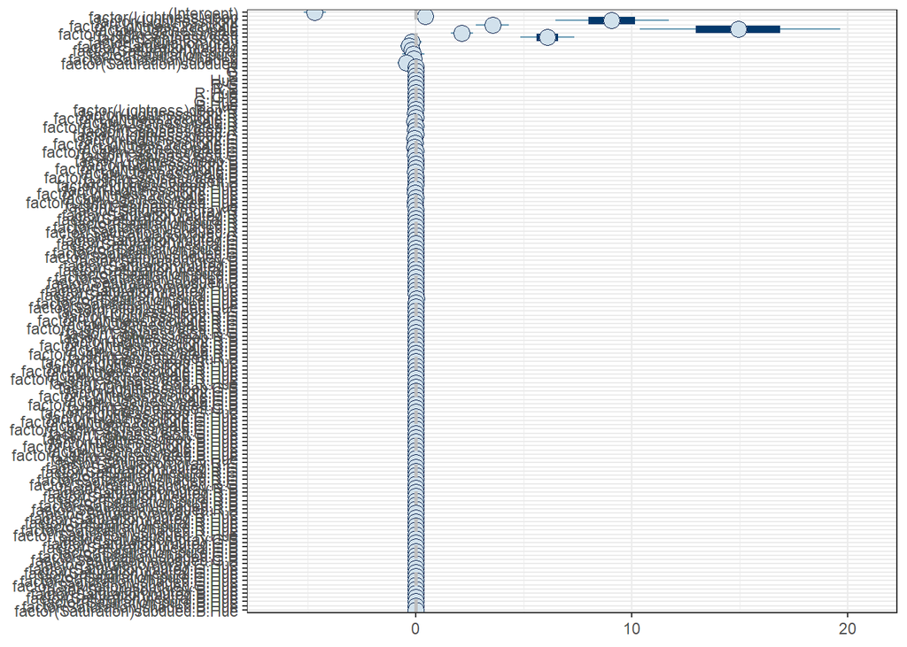

```r
plot(bayesian_model_7_rd,  pars = names(bayesian_model_7_rd$coefficients)) + theme_bw()+
  geom_vline(xintercept = 0, color = "grey", linetype = "dashed", size = 1.) +
  theme_bw()
```

### Note::

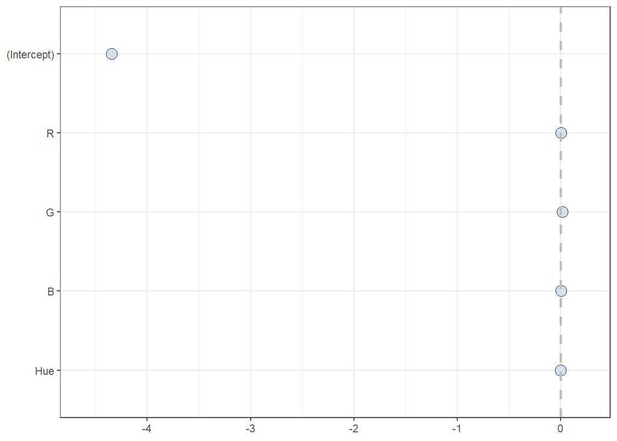

```r
plot(bayesian_model_3_rd,  pars = names(bayesian_model_3_rd$coefficients)) + theme_bw()+
  geom_vline(xintercept = 0, color = "grey", linetype = "dashed", size = 1.) +
  theme_bw()
```

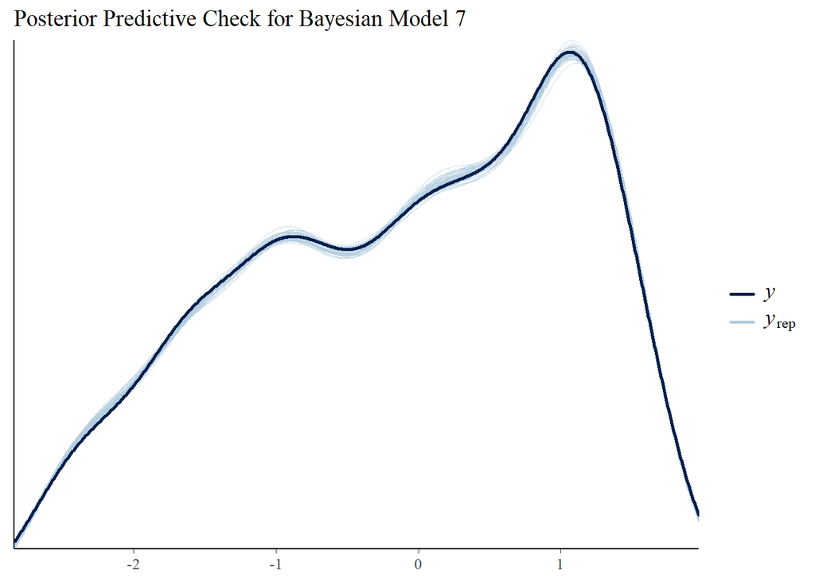

```r
pp_check(bayesian_model_7_rd) + ggtitle("Posterior Predictive Check for Bayesian Model 7")
```

### this uncertainty in this module is lower, so It’s a bitter fit for the data.

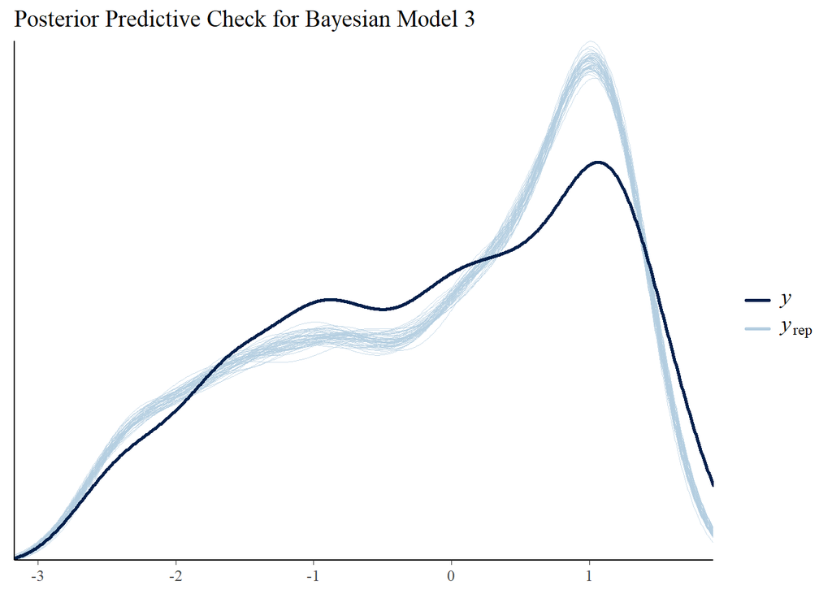

```r
pp_check(bayesian_model_3_rd) + ggtitle("Posterior Predictive Check for Bayesian Model 3")
```

## inconclusion, the modle 7 has liss noise form modle 3. modle 7 is more precise than modwel3.

the distribution on sigma

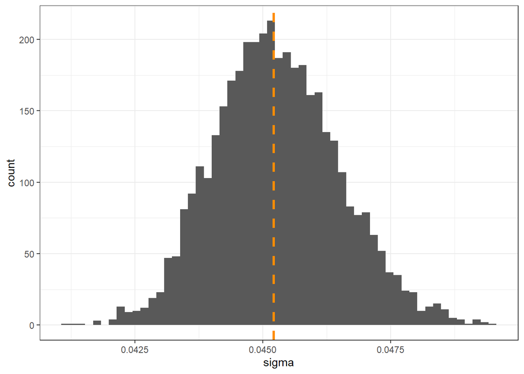

```r
as.data.frame(bayesian_model_7_rd) %>% tibble::as_tibble() %>%
  ggplot(mapping = aes(x = sigma)) +
  geom_histogram(bins = 55) +
  geom_vline(xintercept = stats::sigma(bayesian_model_7_rd),
             color = "darkorange", linetype = "dashed", size = 1.1) +
  theme_bw()
```

## credible interval:

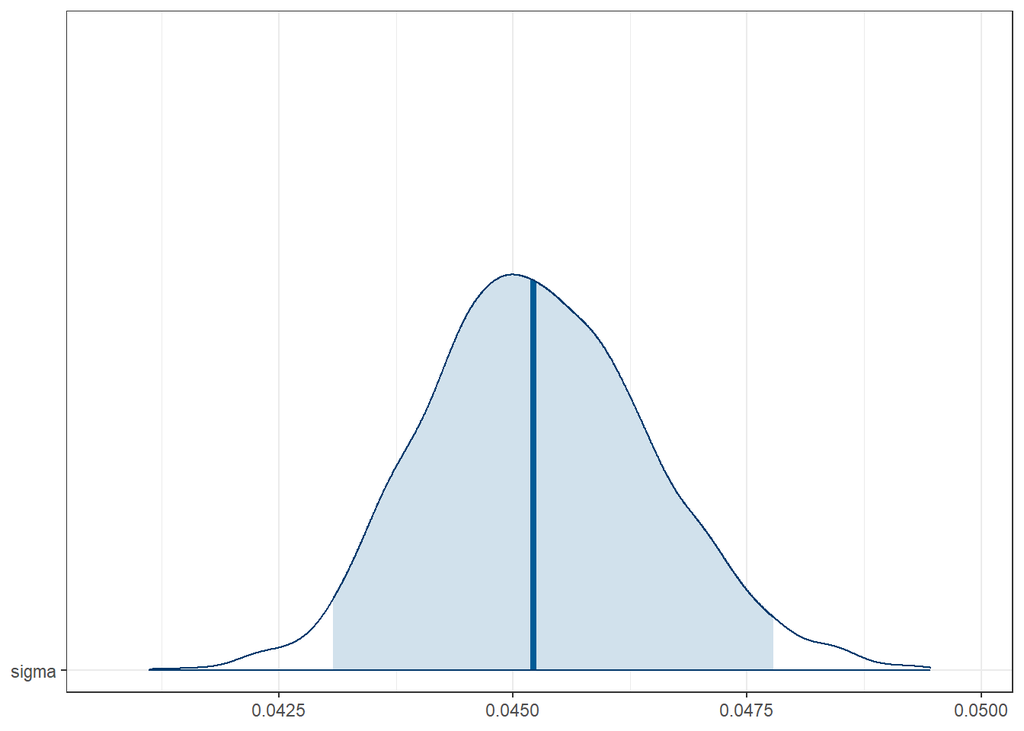

```r
library(bayesplot)
sigma_samples <- as.array(bayesian_model_7_rd, pars = "sigma")

mcmc_areas(sigma_samples, prob = 0.95) + theme_bw()
```

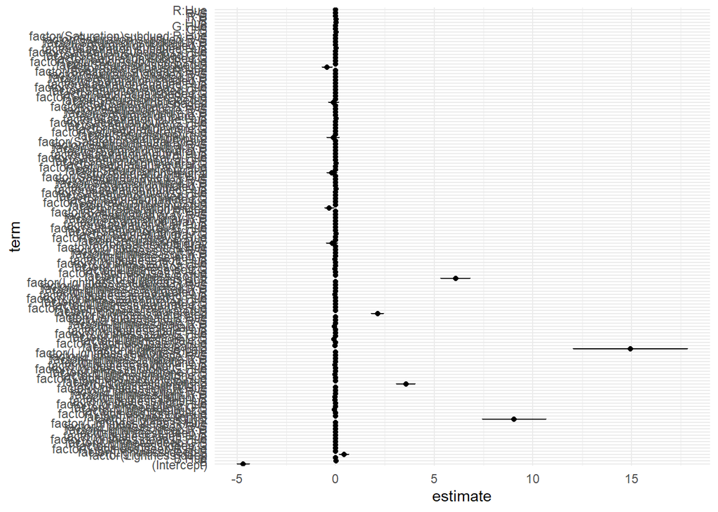

```
The Bayesian analysis shows a range of possible values for the noise in the model, indicating some uncertainty in its exact value. This is in contrast to the single point estimate given by traditional methods like lm(), which do not express this uncertainty.
```

```r
tidy(bayesian_model_7_rd) %>%
ggplot(aes(x = term, y = estimate)) +
  geom_point() +
  geom_errorbar(aes(ymin = estimate - std.error, ymax = estimate + std.error), width = 0.2) +
  coord_flip() +
  theme_minimal()
```

###Part ii: Regression iiC ) Linear models Predictions:

## A) Data Predictions:

```r
tidy_predict <- function(mod, xnew)
{
  pred_df <- predict(mod, xnew, interval = "confidence") %>%
    as.data.frame() %>% tibble::as_tibble() %>%
    dplyr::select(pred = fit, ci_lwr = lwr, ci_upr = upr) %>%
    bind_cols(predict(mod, xnew, interval = 'prediction') %>%
                as.data.frame() %>% tibble::as_tibble() %>%
                dplyr::select(pred_lwr = lwr, pred_upr = upr))

  xnew %>% bind_cols(pred_df)
}
```

```r
predictions_7 <- tidy_predict (model_7,  df_test)
predictions_8 <- tidy_predict (model_8,  df_test)
```

```r
ylim_lower <- min(predictions_7$ci_lwr, na.rm = TRUE) * 1.1
ylim_upper <- max(predictions_7$ci_upr, na.rm = TRUE) * 1.1
```

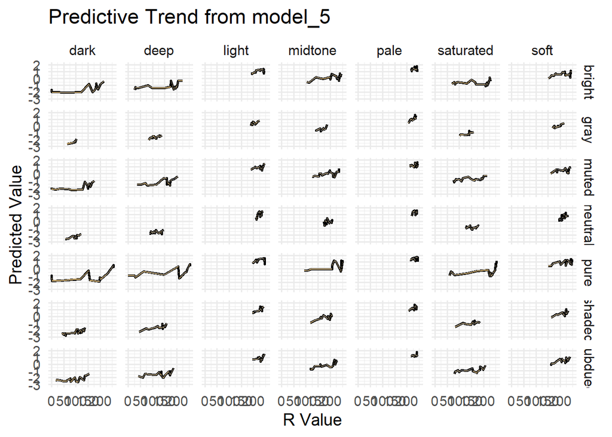

```r
ggplot(predictions_7, aes(x = R, y = pred)) +
  geom_line(color = 'black', size = 1) +
  geom_ribbon(aes(ymin = ci_lwr, ymax = ci_upr),
              fill = 'orange', alpha = 0.70) +
  geom_ribbon(aes(ymin = pred_lwr, ymax = pred_upr),
              fill = 'grey', alpha = 0.50) +
  facet_grid(Saturation   ~ Lightness, scales = "free_y") +
  theme_minimal(base_size = 14) +

  scale_x_continuous(breaks = seq(0, 200, by = 50)) +
  coord_cartesian(ylim  = c(ylim_lower, ylim_upper)) +
  labs(x = "R Value", y = "Predicted Value",
       title = "Predictive Trend from model_5",
       fill = "Interval Type")
```

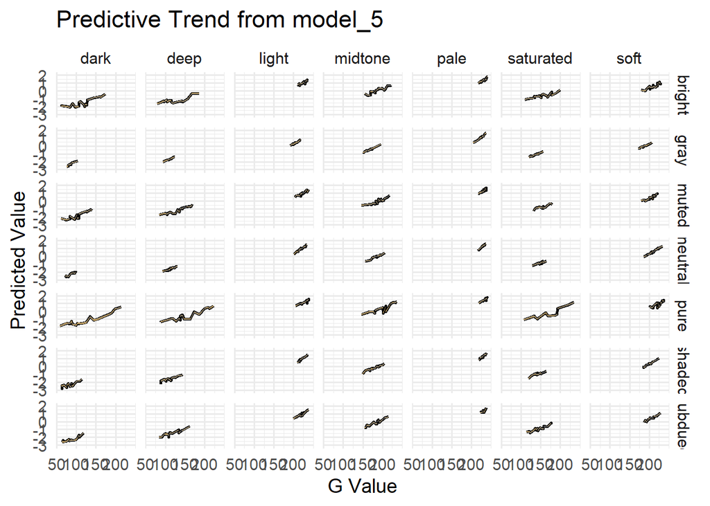

```r
ggplot(predictions_7, aes(x = G, y = pred)) +
  geom_line(color = 'black', size = 1) +
  geom_ribbon(aes(ymin = ci_lwr, ymax = ci_upr),
              fill = 'orange', alpha = 0.70) +
  geom_ribbon(aes(ymin = pred_lwr, ymax = pred_upr),
              fill = 'grey', alpha = 0.50) +
  facet_grid(Saturation   ~ Lightness) +
  theme_minimal(base_size = 14) +

  scale_x_continuous(breaks = seq(0, 200, by = 50)) +
  coord_cartesian(ylim  = c(ylim_lower, ylim_upper)) +
  labs(x = "G Value", y = "Predicted Value",
       title = "Predictive Trend from model_5",
       fill = "Interval Type")
```

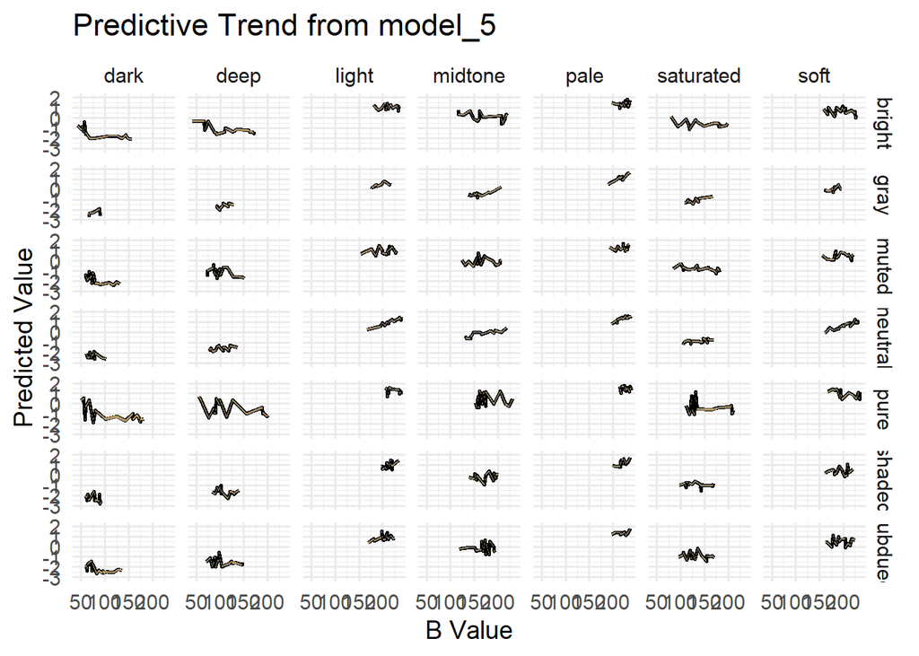

```r
ggplot(predictions_7, aes(x = B, y = pred)) +
  geom_line(color = 'black', size = 1) +
  geom_ribbon(aes(ymin = ci_lwr, ymax = ci_upr),
              fill = 'orange', alpha = 0.70) +
  geom_ribbon(aes(ymin = pred_lwr, ymax = pred_upr),
              fill = 'grey', alpha = 0.50) +
  facet_grid(Saturation   ~ Lightness) +
  theme_minimal(base_size = 14) +

  scale_x_continuous(breaks = seq(0, 200, by = 50)) +
  coord_cartesian(ylim  = c(ylim_lower, ylim_upper)) +
  labs(x = "B Value", y = "Predicted Value",
       title = "Predictive Trend from model_5",fill = "Interval Type")
```

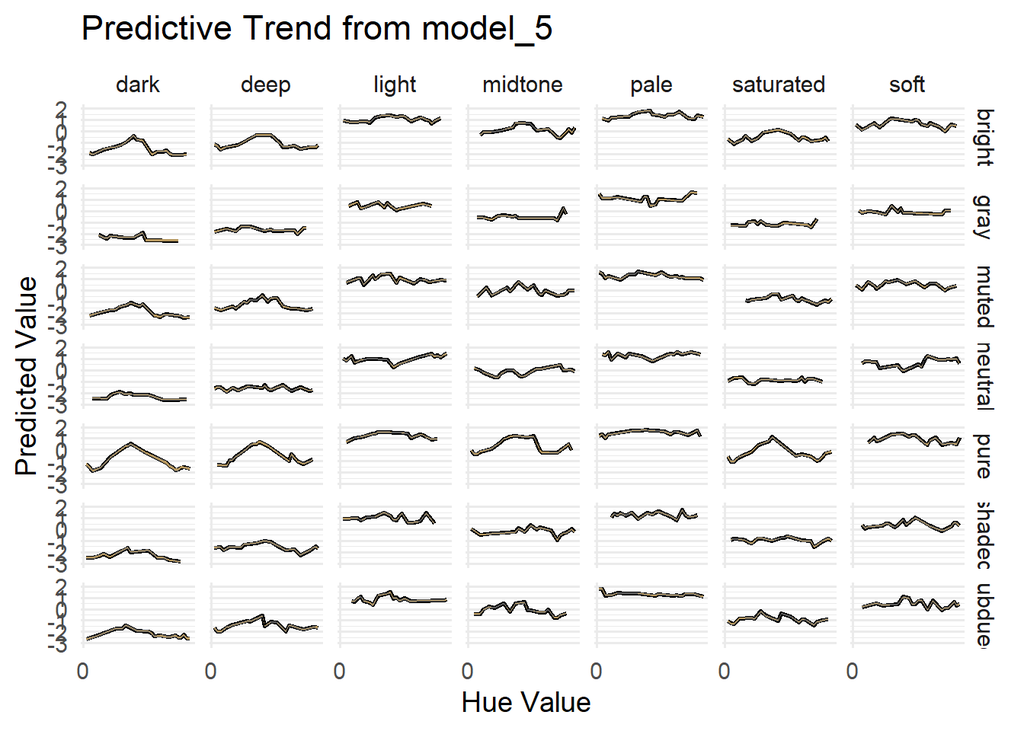

```r
ggplot(predictions_7, aes(x =  Hue, y = pred)) +
  geom_line(color = 'black', size = 1) +
  geom_ribbon(aes(ymin = ci_lwr, ymax = ci_upr),
              fill = 'orange', alpha = 0.70) +
  geom_ribbon(aes(ymin = pred_lwr, ymax = pred_upr),
              fill = 'grey', alpha = 0.50) +
  facet_grid(Saturation   ~ Lightness) +
  theme_minimal(base_size = 14) +

  scale_x_continuous(breaks = seq(0, 200, by = 50)) +
  coord_cartesian(ylim  = c(ylim_lower, ylim_upper)) +
  labs(x = " Hue Value", y = "Predicted Value",
       title = "Predictive Trend from model_5",fill = "Interval Type")
```